# Assignment 5

Manning Smith

10/22/2024

## Data Dictionary of the dataset

- ID: Subject Identifier
- ALIVE: 1–infant alive; 2—infant not alive;
- BF5EVER: Breastfeed–ever, 1=No, 2=Yes.
- BF5LNGTH: duration – length of time in weeks
- PGWT_GN: Pregnant weight gain/lost
- MOM_CM: Moms height – centimeters
- MOM_BMI: MOM BODY MASS INDEX
- MOMCIG: Number of Cigarettes Per Day
- CIG_PRIOR : No. of cigarettes smoked - prior to pregnant
- MOM_LBKG : Moms weight – before pregnant

## Import Data

```r
pramData <- read.csv("PRAMSZZSept.csv")
imputedALIVE <- read.csv("imputed_ALIVE.csv")

#View(pramData)
#View(imputedALIVE)
```

# Part 1

**Bayes Rule**
$$p(A|B)=\frac{P(B|A)P(A)}{P(B)}$$

We have:

$$\begin{aligned}
F = P(F) &= .90 \\
M = P(M) &= .1 \\
P(R|M) &= .95 \\
P(R|F) &= .08 \\
F \cup M &= \Omega
\end{aligned}$$

We want:

$$\begin{aligned}
P(M|R) &= \\
&= \frac{P(R|M)P(M)}{P(R)}\\
P(R) &= \text{ ?}
\end{aligned}$$

See that we can calculate the value of $P(R)$ as

$$\begin{aligned}
P(R) &= P(R|M)P(M) + P(R|F)P(F) \\
&= (.95)(.1) + (.08)(.9) = .167 \\
\\
P(M|R) &= \frac{(.95)(.1)}{(.167)} \\
&= .57
\end{aligned}$$
Notice that $P(M|R)=.57$, meaning that given there is a rash the probability that it is measles causing the rash is $57%$. I would say that the doctors have the wrong impression that there is a $95%$ chance that the child as measles. We save safely say that there is closer to a $50/50$ chance that the child has measles. Intuitively, this can be rationed from the idea that measles is considerably less prevalent in the population thus even though it is more likely to have a rash associated to it, due to the low volume of measles cases there is less of a chance the child contracted measles.

# Part 2

## Question 1

**We will try to predict** `BF5EVER`.  
**Predictors:** `PGWT_GN,MOM_CM, MOM_BMI, MOMCIG, CIG_PRIOR, MOM_LBKG`.  
**Model:** `BF5EVER ~ PGWT_GN + MOM_CM + MOM_BMI + MOMCIG + CIG_PRIOR + MOM_LBKG`.

## Question 2

## 2a)

**Using “featurePlot“ in “caret” to obtain Feature plots, Scatter Plot Matrix, and Box-Plots.**

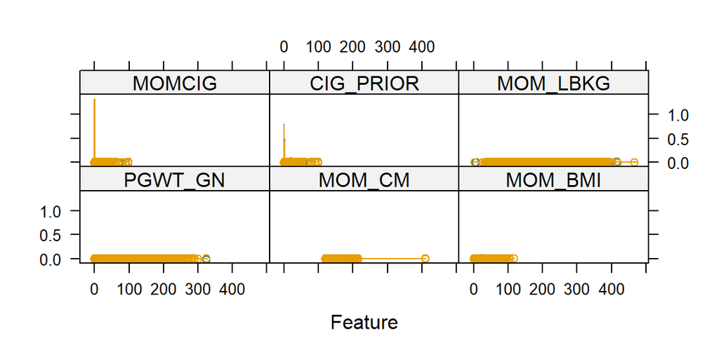

```r
caret::featurePlot(x = imputedALIVE[, c("PGWT_GN", "MOM_CM", "MOM_BMI", "MOMCIG", "CIG_PRIOR", "MOM_LBKG")],
            y = as.factor(imputedALIVE$BF5EVER),
            plot = "density")
```

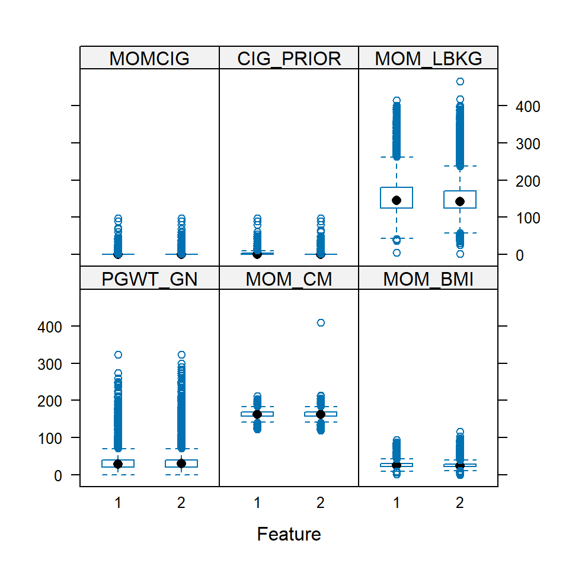

```r
caret::featurePlot(x = imputedALIVE[, c("PGWT_GN", "MOM_CM", "MOM_BMI", "MOMCIG", "CIG_PRIOR", "MOM_LBKG")],
            y = as.factor(imputedALIVE$BF5EVER),
            plot = "box")
```

[figure not shown]

```r
caret::featurePlot(x = imputedALIVE[, c("PGWT_GN", "MOM_CM", "MOM_BMI", "MOMCIG", "CIG_PRIOR", "MOM_LBKG")],
            y = as.factor(imputedALIVE$BF5EVER),
            plot = "pairs")
```

### 2b)

**Fit a multiple naïve Bayes model to predict the response using the six predictors. Describe your results,including prior probabilities, Conditional probabilities, predictions, and Accuracy.**

```r
naive_model <- naive_bayes(as.factor(BF5EVER) ~ PGWT_GN + MOM_CM + MOM_BMI + MOMCIG + CIG_PRIOR + MOM_LBKG, data = imputedALIVE)
summary(naive_model)
```

```
##
## ================================= Naive Bayes ==================================
##
## - Call: naive_bayes.formula(formula = as.factor(BF5EVER) ~ PGWT_GN +      MOM_CM + MOM_BMI + MOMCIG + CIG_PRIOR + MOM_LBKG, data = imputedALIVE)
## - Laplace: 0
## - Classes: 2
## - Samples: 189159
## - Features: 6
## - Conditional distributions:
##     - Gaussian: 6
## - Prior probabilities:
##     - 1: 0.1669
##     - 2: 0.8331
##
## --------------------------------------------------------------------------------
```

**Conditional Probabilities:**  
This naive bayes model assumes a Gaussian distributions for the predictors.

```r
# Model Tables
naive_model$tables
```

```
## --------------------------------------------------------------------------------
## :: PGWT_GN (Gaussian)
## --------------------------------------------------------------------------------
##
## PGWT_GN        1        2
##    mean 30.42799 31.47664
##    sd   20.57787 19.33562
##
## --------------------------------------------------------------------------------
## :: MOM_CM (Gaussian)
## --------------------------------------------------------------------------------
##
## MOM_CM          1          2
##   mean 162.585411 163.233482
##   sd     7.573093   7.603656
##
## --------------------------------------------------------------------------------
## :: MOM_BMI (Gaussian)
## --------------------------------------------------------------------------------
##
## MOM_BMI         1         2
##    mean 26.781210 25.856626
##    sd    7.229449  6.379840
##
## --------------------------------------------------------------------------------
## :: MOMCIG (Gaussian)
## --------------------------------------------------------------------------------
##
## MOMCIG         1         2
##   mean 2.2949226 0.6973881
##   sd   5.3812253 2.9780844
##
## --------------------------------------------------------------------------------
## :: CIG_PRIOR (Gaussian)
## --------------------------------------------------------------------------------
##
## CIG_PRIOR        1        2
##      mean 3.968927 1.463785
##      sd   8.365314 5.209124
##
## --------------------------------------------------------------------------------
## :: MOM_LBKG (Gaussian)
## --------------------------------------------------------------------------------
##
## MOM_LBKG         1         2
##     mean 156.30458 150.70097
##     sd    45.07990  40.62487
##
## --------------------------------------------------------------------------------
```

In summary, mothers who breastfed gained slightly more weight on average during pregnancy. There is no difference in height of mothers. The mother BMI was slightly lower for those who breastfed. Non-breastfeeding mothers smoked more cigarettes on average. For cigarettes before pregnancy, results were similar to that of smoked during pregnancy. Lastly, mothers not breastfeeding had a higher pre pregnancy weight.

```r
# Makes Predictions
predictions <- predict(naive_model, imputedALIVE)
# Form confusion Matrix
confusionMatrix(predictions, as.factor(imputedALIVE$BF5EVER))
```

```
## Confusion Matrix and Statistics
##
##           Reference
## Prediction      1      2
##          1   6098  10686
##          2  25473 146902
##
##                Accuracy : 0.8088
##                  95% CI : (0.8071, 0.8106)
##     No Information Rate : 0.8331
##     P-Value [Acc > NIR] : 1
##
##                   Kappa : 0.1542
##
##  Mcnemar's Test P-Value : <2e-16
##
##             Sensitivity : 0.19315
##             Specificity : 0.93219
##          Pos Pred Value : 0.36332
##          Neg Pred Value : 0.85222
##              Prevalence : 0.16690
##          Detection Rate : 0.03224
##    Detection Prevalence : 0.08873
##       Balanced Accuracy : 0.56267
##
##        'Positive' Class : 1
##
```

## Question 3

**We will try to predict** `BF5EVER`.  
**Predictors:** `PGWT_GN, MOM_CM, MOM_BMI, MOMCIG, CIG_PRIOR, MOM_LBKG`.  
**Model:** `BF5EVER ~ PGWT_GN + MOM_CM + MOM_BMI + MOMCIG + CIG_PRIOR + MOM_LBKG`.

### 3a)

**Fit a linear discriminant model to predict the response using the six predictors. Describe your results, including priori probabilities of groups, group means, coefficients of linear discriminant, predictions and Accuracy.**

```r
# Split Data
trainIndex <- createDataPartition(imputedALIVE$BF5EVER, p = 0.7, list = FALSE, times = 1)
data_trn <- imputedALIVE[trainIndex, ]
data_tst <- imputedALIVE[-trainIndex, ]
```

Source for spiting the data set.[^2]

```r
# LDA Model
alive_lda = lda(BF5EVER ~ PGWT_GN + MOM_CM + MOM_BMI + MOMCIG + CIG_PRIOR + MOM_LBKG, data = data_trn)
#alive_lda
```

LDA code taking from notes provided in the module.

**Prior Probabilities:**

```r
alive_lda$prior
```

```
##         1         2
## 0.1674773 0.8325227
```

**Group Means:**

```r
kable(alive_lda$counts, caption = "Counts", format = "html")
```

Counts

| x |
| --- |
| 22176 |
| 110236 |

```r
kable(alive_lda$means, caption = "Group Means", format = "html")
```

Group Means

| PGWT_GN | MOM_CM | MOM_BMI | MOMCIG | CIG_PRIOR | MOM_LBKG |
| --- | --- | --- | --- | --- | --- |
| 30.51696 | 162.5874 | 26.74257 | 2.2738997 | 3.972583 | 156.1217 |
| 31.44895 | 163.2122 | 25.85993 | 0.6995083 | 1.461954 | 150.6719 |

- `PGWT_GN`: Mothers who did not breastfeed gained slightly less weight during pregnancy on average.
- `MOM_CM`: The height difference between the two groups is minimal.
- `MOM_BMI`: Non-breastfeeding mothers have a higher average BMI.
- `MOMCIG`: Non-breastfeeding mothers smoke more cigarettes per day on average.
- `CIG_PRIOR`: Non-breastfeeding mothers smoked more prior to pregnancy.
- `MOM_LBKG`: Mothers who breastfed had lower average weights before pregnancy.

**coefficients of linear Discriminants:**

```r
coefDiscrim <- data.frame(
  Variable = c("PGWT_GN", "MOM_CM", "MOM_BMI", "MOMCIG", "CIG_PRIOR", "MOM_LBKG"),
  LD1 = c(0.003902853, 0.060731142, 0.083359371, -0.164828374, -0.068187890, -0.021325825)
)

kable(coefDiscrim, caption = "Coefficients of linear discriminants", format = "html")
```

Coefficients of linear discriminants

| Variable | LD1 |
| --- | --- |
| PGWT_GN | 0.0039029 |
| MOM_CM | 0.0607311 |
| MOM_BMI | 0.0833594 |
| MOMCIG | -0.1648284 |
| CIG_PRIOR | -0.0681879 |
| MOM_LBKG | -0.0213258 |

*Positive coefficients:*  
`PGWT_GN, MOM_CM, MOM_BMI`. These indicate that higher values are associated with increased odds of breastfeeding.

*Negative coefficients:*  
`MOMCIG, CIG_PRIOR, MOM_LBKG`. These indicate that higher values are associated with decreased odds of breastfeeding. Therefore, the results suggest that smoking and a lower pre-pregnancy weight of the mother may influence breastfeeding.

**Predictions and Accuracy:**

```r
# Predict
data_trn_pred <- predict(alive_lda, data_trn)
data_tst_pred <- predict(alive_lda, data_tst)

# Store Predictions
predictions_trn <- data_trn_pred$class
predictions_tst <- data_tst_pred$class

# Calculate classification error
calc_class_err <- function(actual, predicted) {
  mean(actual != predicted)
}

# Check accuracy on the training set
accuracy_trn <- mean(predictions_trn == data_trn$BF5EVER)

# Check accuracy on the test set
accuracy_tst <- mean(predictions_tst == data_tst$BF5EVER)

# Create confusion matrices
conf_matrix_trn <- table(predictions_trn, data_trn$BF5EVER)
conf_matrix_tst <- table(predictions_tst, data_tst$BF5EVER)

# Output results
accuracy_trn
```

```
## [1] 0.8293961
```

```r
accuracy_tst
```

```
## [1] 0.832837
```

```r
kable(conf_matrix_trn, caption = "Coefficient Matrix of Train | LDA", format = "html")
```

Coefficient Matrix of Train | LDA

| 1 | 2 |
| --- | --- |
| 1205 | 1619 |
| 20971 | 108617 |

```r
kable(conf_matrix_tst, caption = "Coefficient Matrix of Test  | LDA", format = "html")
```

Coefficient Matrix of Test | LDA

| 1 | 2 |
| --- | --- |
| 556 | 647 |
| 8839 | 46705 |

**Summary:**  
The model indicated that the training dataset showed a higher proportion of mothers who breastfed their infants. Group means revealed that non-breastfeeding mothers tended to have a higher BMI, smoke more cigarettes, and gained slightly less weight during pregnancy. On the other hand, breastfeeding mothers had a lower pre-pregnancy weights, in general. From the linear discriminant analysis, we achieved enough of an approximate to suggest the effectiveness of classifying the status of breastfeeding, However, there are challenges in predicting non-breastfeeding due to the influence of smoking and pre-pregnancy weight for the decisions of breastfeeding.[^3]